# Statistics Project Visualizations

```r
age_gender_stats <- decoded_data %>%
  filter(!is.na(E14_1), !is.na(Age_16groups), !is.na(B3)) %>%
  group_by(Age_16groups, B3) %>%
  summarize(
    mean_salary = mean(E14_1),
    se = sd(E14_1) / sqrt(n()),
    lower_ci = mean_salary - 1.96 * se,
    upper_ci = mean_salary + 1.96 * se,
    n = n(),
    .groups = "drop"
  ) %>%
  filter(n >= 10) %>%
  mutate(salary_label = paste0(format(round(mean_salary), big.mark = ",")))
```

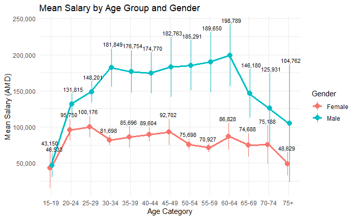

```r
ggplot(age_gender_stats,
       aes(x = Age_16groups, y = mean_salary,
           color = B3, group = B3)) +
  geom_line(linewidth = 1.2) +
  geom_pointrange(
    aes(ymin = lower_ci, ymax = upper_ci),
    position = position_dodge(width = 0.2),
    size = 0.7
  ) +
  geom_text(aes(y = upper_ci, label = salary_label),
            position = position_dodge(width = 0.5),
            vjust = -0.5, size = 3, color = "black") +
  labs(
    title = "Mean Salary by Age Group and Gender",
    x = "Age Category",
    y = "Mean Salary (AMD)",
    color = "Gender"
  ) +
  scale_y_continuous(labels = scales::comma) +
  theme_minimal()
```

Findings: In this chart, we have considered the records where the implicit salaries are mentioned. We can see that the salary of males in the sample is considerably higher and the condifence interval is bigger. However, the length of confidence intervals for the mean salary of males are longer, which means that we are not as much certain about the mean as for the females. The lower bounds of the confidence intervals of males’ mean salaries are closers to the females’ mean salaries.

*Mean Salary with 95% Confidence Intervals*

```r
decoded_data <- decoded_data%>%
  mutate(
    B8 = case_when(
      B8 == 1 ~ "Up tp 2000",
      B8 == 2 ~ "2001-2005",
      B8 == 3 ~ "2006-2010",
      B8 == 4 ~ "Since 2012"

    )
  )
```

Based on the salary they have provided.

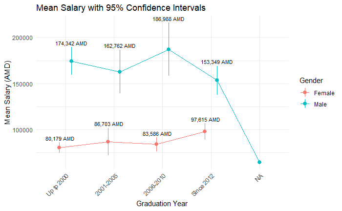

```r
correct_order <- c("Up tp 2000", "2001-2005", "2006-2010", "Since 2012")

plot_data <- decoded_data %>%
  mutate(
    graduation_year_ordered = factor(
      B8,
      levels = correct_order,
      ordered = TRUE
    )
  ) %>%
  filter(!is.na(E14_1)) %>%
  group_by(graduation_year_ordered, B3) %>%  # Group by the ordered factor
  summarize(
    mean_salary = mean(E14_1),
    se = sd(E14_1) / sqrt(n()),
    lower_ci = mean_salary - 1.96 * se,
    upper_ci = mean_salary + 1.96 * se,
    .groups = "drop"  # Explicitly drop grouping
  ) %>%
  mutate(salary_label = paste0(format(round(mean_salary), big.mark = ","), " AMD"))


ggplot(plot_data, aes(x = graduation_year_ordered, y = mean_salary,
                     color = B3, group = B3)) +
  geom_pointrange(aes(ymin = lower_ci, ymax = upper_ci),
                 position = position_dodge(width = 0.5)) +
  geom_line(position = position_dodge(width = 0.5)) +
  geom_text(aes(y = upper_ci, label = salary_label),
            position = position_dodge(width = 0.5),
            vjust = -0.5, size = 3, color = "black") +
  labs(title = "Mean Salary with 95% Confidence Intervals",
       x = "Graduation Year", y = "Mean Salary (AMD)",
       color = "Gender") +
  theme_minimal() +
  theme(axis.text.x = element_text(angle = 45, hjust = 1))
```

Let’s also see the count of men and women based on the graduation year.

```r
library(dplyr)

graduation_summary <- decoded_data %>%
  filter(!is.na(B3), !is.na(B8)) %>%
  count(Gender = B3, Graduation_Year = B8, name = "Count") %>%

  group_by(Graduation_Year) %>%
  mutate(Percentage = Count / sum(Count) * 100) %>%
  ungroup() %>%

  mutate(Percentage_Label = paste0(round(Percentage, 1), "%")) %>%

  select(Gender, Graduation_Year, Count, Percentage, Percentage_Label) %>%
  arrange(Graduation_Year, Gender)

print(graduation_summary)
```

| Gender | Graduation_Year | Count | Percentage | Percentage_Label |
| --- | --- | --- | --- | --- |
| Female | 2001-2005 | 528 | 43.27869 | 43.3% |
| Male | 2001-2005 | 692 | 56.72131 | 56.7% |
| Female | 2006-2010 | 472 | 38.75205 | 38.8% |
| Male | 2006-2010 | 746 | 61.24795 | 61.2% |
| Female | Since 2012 | 618 | 35.07378 | 35.1% |
| Male | Since 2012 | 1144 | 64.92622 | 64.9% |
| Female | Up tp 2000 | 2746 | 46.48722 | 46.5% |
| Male | Up tp 2000 | 3161 | 53.51278 | 53.5% |

*Can We Find the Mean Salary by Work Location and Gender*

| J3_1 |
| --- |
| NA |

It comes out that we cannot work with columns J3_1 and J3_2, which specify if the survey taker works in Armenia/abroad/both/no paid job. The reason is that when cleaning the data, we kept only the records where salary range or exact salary is mentioned.

```r
decoded_data <- decoded_data%>%
  mutate(
    E10 = case_when(
      E10 == 1 ~ "Public",
      E10 == 2 ~ "NGO",
      E10 == 3 ~ "Private",
      E10 == 4 ~ "Self-emplyed"
    )
  ) %>%
  mutate(
    F6 = case_when(
      F6 == 1 ~ "Public",
      F6 == 2 ~ "NGO",
      F6 == 3 ~ "Private",
      F6 == 4 ~ "Self-employed"
    )
  )
```

Let’s see how many records we have with filled primary job and secondary ones.

```r
primary_job_count <- decoded_data %>%
  filter(!is.na(E10)) %>%
  count(B3, name = "count")
primary_job_count
```

| B3 | count |
| --- | --- |
| Female | 4364 |
| Male | 5746 |

```r
secondary_job_count <- decoded_data %>%
  filter(!is.na(F6)) %>%
  count(B3, name = "count")
secondary_job_count
```

| B3 | count |
| --- | --- |
| Female | 178 |
| Male | 407 |

```r
NA
```

```r
plot_data <- decoded_data %>%
  select(gender = B3, salary = E14_1, ownership = E10) %>%
  filter(!is.na(salary), !is.na(ownership)) %>%
  mutate(ownership = factor(ownership))

summary_stats <- plot_data %>%
  group_by(gender, ownership) %>%
  summarize(
    mean_salary = mean(salary),
    se = sd(salary) / sqrt(n()),
    lower_ci = mean_salary - 1.96 * se,
    upper_ci = mean_salary + 1.96 * se,
    n = n(),
    .groups = "drop"
  ) %>%
  filter(n >= 10)
```

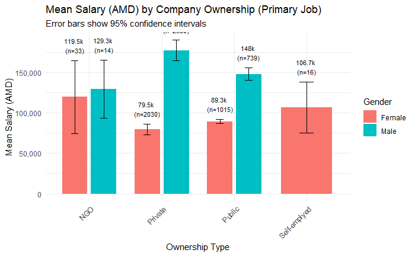

```r
ggplot(summary_stats,
       aes(x = ownership, y = mean_salary, fill = gender)) +
  geom_col(position = position_dodge(width = 0.8), width = 0.7) +
  geom_errorbar(
    aes(ymin = lower_ci, ymax = upper_ci),
    position = position_dodge(width = 0.8),
    width = 0.2,
    color = "black"
  ) +
  geom_text(
    aes(label = paste0(round(mean_salary/1000, 1), "k \n(n=", n, ")"),
        y = upper_ci),
    position = position_dodge(width = 0.8),
    vjust = -0.5,
    size = 3
  ) +
  labs(
    title = "Mean Salary (AMD) by Company Ownership (Primary Job)",
    subtitle = "Error bars show 95% confidence intervals",
    x = "Ownership Type",
    y = "Mean Salary (AMD)",
    fill = "Gender"
  ) +
  scale_y_continuous(labels = scales::comma) +
  theme_minimal() +
  theme(axis.text.x = element_text(angle = 45, hjust = 1))
```

Findings: In this chart, we have considered the records where the implicit salaries are mentioned. Concentrating on the chart above, we can see that only females are recorded as self-employed (keeping in mind that the data is filtered to keep only records with mentioned salary). Hte analysis also shows that males earch more in NGOs, Private and Public enterprises, but the highest difference is in Private companies. Although there are more females who answered this questions then males, but the difference still exists.